# Appendix B: Seasonal variation of the load regimes

This appendix asks a single, focused question: is the three-regime structure of the hourly load factor (and its diurnal cycle) stable across the seasons, or does the weight/timing of the regimes shift?

Before interpreting the seasonal distributions, two critical constraints regarding the dataset and the context must be established:

1. **The load factor is normalized day-by-day on its own peak.** A seasonal difference therefore does **not** reflect the level of consumption (for instance, higher absolute summer load from cooling disappears under the normalization): it reflects only the **shape** of the daily load curve.
2. **Ramadan has a strong lifestyle influence.** In Morocco the daily activity pattern changes during Ramadan (activity shifted to the evening/night). In 2017 Ramadan ran from about **27 May to 24 June**, straddling late spring and early summer, so any apparent “summer effect” could in fact be a Ramadan effect. We treat the Ramadan window as a **separate group** so it cannot silently contaminate the seasonal comparison.

We project the global $H=3$ fit and its mean-ordered maximum a posteriori (MAP) component assignments ($\hat{z}_i$) onto the partitioned dataset, allowing us to evaluate the stability of the global regimes.

## Dependencies

Note: this file is meant to be knitted/run **in the same R session, after** `Final_Project.Rmd`, so that the global objects are available in memory.

## Deriving the season and the Ramadan window

We map each observation’s calendar `date` to a meteorological season (3 months per season: DJF / MAM / JJA / SON) and flag the Ramadan-2017 window. Observations falling in Ramadan are pulled out into their own group, so “Summer (JJA)” below means *summer excluding Ramadan*.

```r
load("bayesian_project_full_workspace.RData")
# Parse dates (CSV format is M/D/YYYY) and extract the month
dates <- as.Date(lf_fit$date, format = "%m/%d/%Y")
if (all(is.na(dates)))
  stop("Date parsing failed: check the format of lf_fit$date (expected M/D/YYYY).")
month <- as.integer(format(dates, "%m"))

# Meteorological season from month
month_to_season <- function(m)
  ifelse(m %in% c(12, 1, 2), "Winter (DJF)",
  ifelse(m %in% 3:5,         "Spring (MAM)",
  ifelse(m %in% 6:8,         "Summer (JJA)",
                             "Autumn (SON)")))

season <- factor(month_to_season(month),
                 levels = c("Winter (DJF)", "Spring (MAM)",
                            "Summer (JJA)", "Autumn (SON)"))

# Ramadan 2017 window (27 May – 24 June 2017)
ramadan_start <- as.Date("2017-05-27")
ramadan_end   <- as.Date("2017-06-24")
is_ramadan    <- !is.na(dates) & dates >= ramadan_start & dates <= ramadan_end

# Grouping variable
grp_chr <- as.character(season)
grp_chr[is_ramadan] <- "Ramadan 2017"
grp <- factor(grp_chr,
              levels = c(levels(season), "Ramadan 2017"))

# A colour per group
grp_levels <- levels(grp)
grp_cols   <- setNames(
  c("steelblue", "darkgreen", "tomato", "goldenrod3", "purple")[seq_along(grp_levels)],
  grp_levels)
```

## B.1 Descriptive analysis

### Group sizes

Before anything else: how many observations fall in each group.

```r
counts <- as.data.frame(table(Group = grp))
names(counts)[2] <- "n"
knitr::kable(counts, caption = "Number of observations per group.")
```

Number of observations per group.

| Group | n |
| --- | --- |
| Winter (DJF) | 475 |
| Spring (MAM) | 463 |
| Summer (JJA) | 389 |
| Autumn (SON) | 490 |
| Ramadan 2017 | 183 |

The groups are balanced enough, meaning we can safely proceed with the analysis.

### Per-group summary statistics of the load factor

```r
summ_by_grp <- do.call(rbind, lapply(grp_levels, function(g) {
  v <- my_data[grp == g]
  data.frame(Group  = g,
             n      = length(v),
             Min    = round(min(v),    3),
             Median = round(median(v), 3),
             Mean   = round(mean(v),   3),
             Max    = round(max(v),    3))
}))
knitr::kable(summ_by_grp, row.names = FALSE,
             caption = "Load-factor summary statistics by group.")
```

Load-factor summary statistics by group.

| Group | n | Min | Median | Mean | Max |
| --- | --- | --- | --- | --- | --- |
| Winter (DJF) | 475 | 0.460 | 0.728 | 0.722 | 0.999 |
| Spring (MAM) | 463 | 0.426 | 0.721 | 0.709 | 0.999 |
| Summer (JJA) | 389 | 0.439 | 0.747 | 0.731 | 0.999 |
| Autumn (SON) | 490 | 0.457 | 0.726 | 0.722 | 0.999 |
| Ramadan 2017 | 183 | 0.439 | 0.760 | 0.751 | 0.999 |

### Empirical density of the load factor by group

If the bounded, multimodal shape that motivated the Beta mixture persists in every season, the global three-regime description is robust; shifts in the location/height of the modes signal a seasonal change in the shape of the daily load curve.

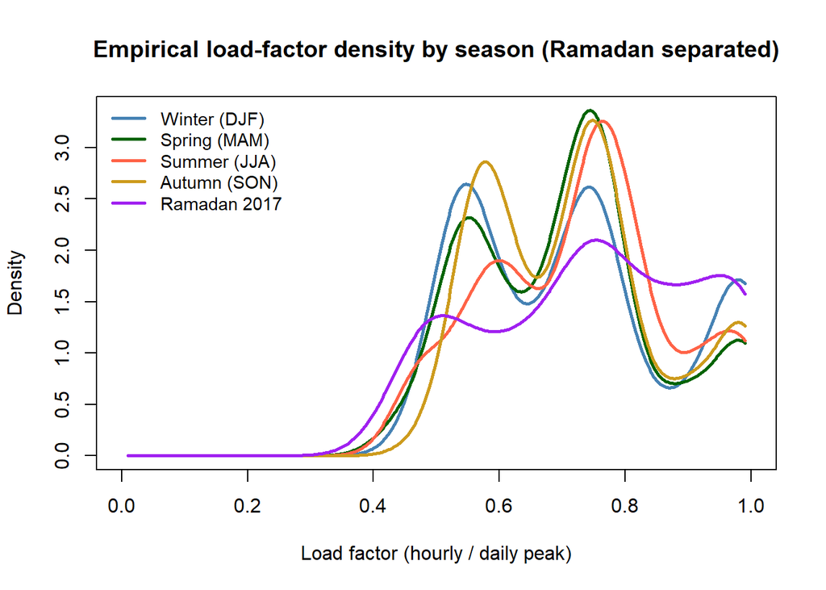

```r
# Pre-compute densities so we can set a common y-axis
dens_list <- lapply(grp_levels, function(g)
  density(my_data[grp == g], from = 0.01, to = 0.99))
names(dens_list) <- grp_levels
ymax <- max(vapply(dens_list, function(d) max(d$y), numeric(1)))

plot(NA, xlim = c(0, 1), ylim = c(0, ymax),
     xlab = "Load factor (hourly / daily peak)", ylab = "Density",
     main = "Empirical load-factor density by season (Ramadan separated)")
for (g in grp_levels)
  lines(dens_list[[g]], col = grp_cols[g], lwd = 2.5)
legend("topleft", legend = grp_levels, col = grp_cols,
       lwd = 2.5, bty = "n", cex = 0.9)
```

As shown in figure above, the bounded multimodal shape that motivated the Beta mixture persists across all seasonal subsets. While the relative mass between the off-peak bulk and the near-peak bulge fluctuates, the overarching structural regimes remain consistent, confirming that the global $H=3$ parameterization is robust across the year.

## B.2 Diurnal regimes by season

We now reuse the global MAP assignment `z_map` and plot, **within each group**, the empirical fraction of observations in each component as a function of `hour`. This is exactly the Task 3 plot, sliced by season, so it exposes whether the timing of the regimes shifts.

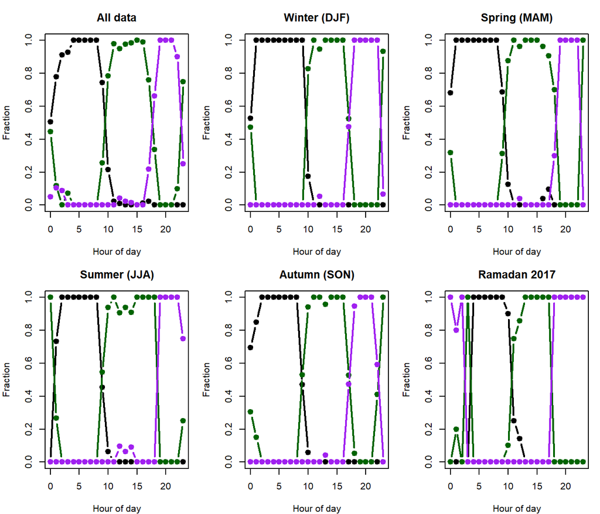

```r
plot_fraction_by_hour <- function(sel, title) {
  tab <- table(factor(hours[sel], levels = 0:23),
               factor(z_map[sel], levels = 1:best_H))
  fm  <- prop.table(tab, margin = 1)   # each hour sums to 1 (NaN where no obs)
  matplot(0:23, as.matrix(fm), type = "b", pch = 19, lty = 1,
          col = COMPONENT_COLS[1:best_H], lwd = 2, ylim = c(0, 1),
          xlab = "Hour of day", ylab = "Fraction", main = title)
}

# One reference panel for all data, then one per group
panels <- c("All data", grp_levels)
par(mfrow = c(2, 3), mar = c(4, 4, 3, 1))
for (p in panels) {
  sel <- if (p == "All data") rep(TRUE, N) else (grp == p)
  plot_fraction_by_hour(sel, p)
}
```

```r
par(mfrow = c(1, 1))
legend_lab <- paste("Component", 1:best_H)
```

The near-peak load curve is visibly shifted during Ramadan, highlighting a delayed and concentrated evening/night peak compared to other seasons.